# Statistical software for climate: extRemes, climextRemes, and NIMBLE

Part 1: extRemes and climextRemes

Chris Paciorek

July 2019

# extRemes and climextRemes

We’ll consider two R packages for fitting statistical extreme value models to data. They build heavily off the material in Coles: An Introduction to Statistical Modeling of Extreme Values.

- `extRemes` is a more general package and provides a wider variety of fitting methods as well as some diagnostics and more general functionality. We’ll see a bit of this but won’t delve into the tail dependence or (limited) spatial dependence features of extRemes.
- `climextRemes` uses extRemes for fitting and provides a small set of fitting methods (maximum likelihood estimation for GEV and POT), but provides
  - a wider variety of return level/value/probability estimates with uncertainty,
  - tools for event attribution and analysis of trends,
  - easier handling of replicates,
  - various tools for ease of use (missing data, scaling of covariates, declustering, low extremes).

# A basic data set - annual maxima

Fort Collins precipitation from the GHCN (provided by extRemes):

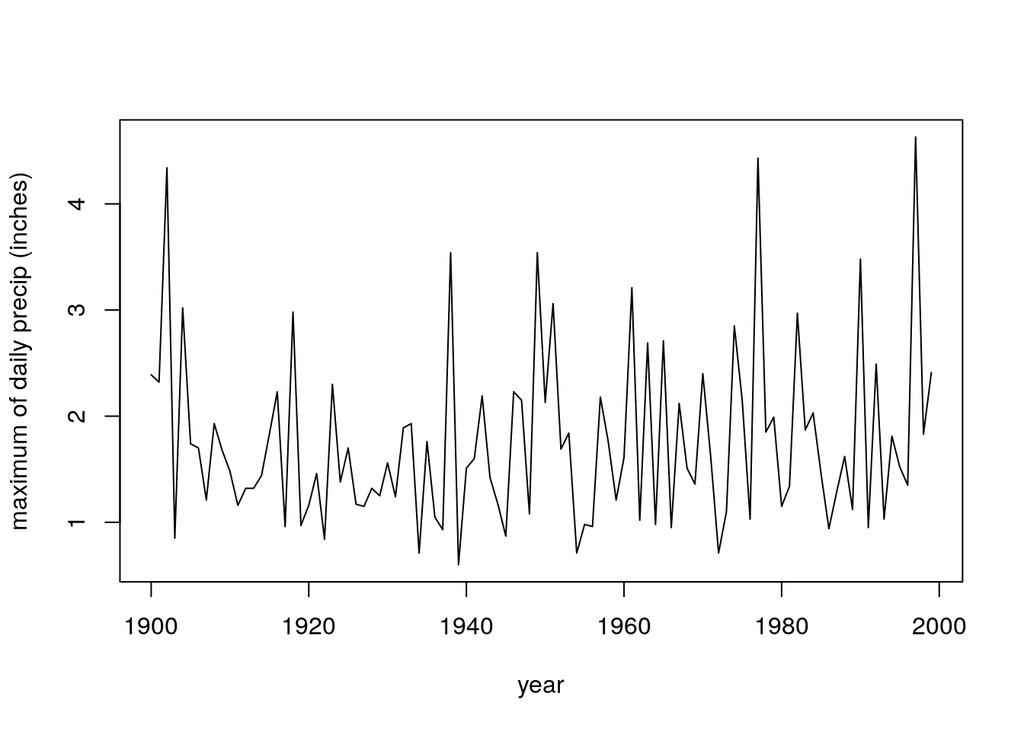

```r
library(extRemes)
data(Fort)

## Plot annual maxes to guide interpretation

FortMax <- aggregate(Prec ~ year, data = Fort, max)
plot(FortMax$year, FortMax$Prec, xlab = 'year', ylab = 'maximum of daily precip (inches)', type = 'l')
```

# A basic data set - peaks over a high threshold

Here is the peaks-over-threshold version of the data.

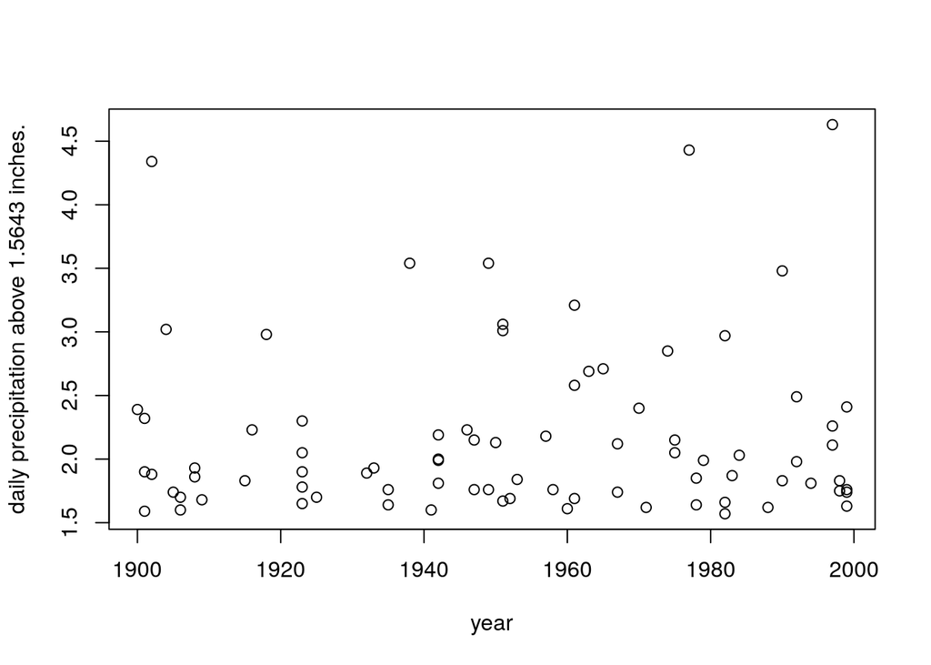

```r
firstBlock <- min(Fort$year)
years <- min(Fort$year):max(Fort$year)
nYears <- length(years)
ord <- order(Fort$year, Fort$month, Fort$day)
Fort <- Fort[ord, ]
threshold <- quantile(Fort$Prec[Fort$Prec > 0], 0.99)
ind <- Fort$Prec > threshold
FortExc <- Fort[ind, ]
plot(FortExc$year, FortExc$Prec, xlab = 'year',
   ylab = paste0('daily precipitation above ', threshold, ' inches.'))
```

```r
head(FortExc)
```

```
##     obs tobs month day year Prec
## 119 119  119     4  29 1900 2.39
## 464 464   99     4   9 1901 1.59
## 505 505  140     5  20 1901 1.90
## 507 507  142     5  22 1901 2.32
## 993 993  263     9  20 1902 1.88
## 994 994  264     9  21 1902 4.34
```

# Some basic fitting with extRemes

```r
## GEV
gev_model <- fevd(FortMax$Prec, type = 'GEV')
gev_model
```

```
##
## fevd(x = FortMax$Prec, type = "GEV")
##
## [1] "Estimation Method used: MLE"
##
##
##  Negative Log-Likelihood Value:  104.9645
##
##
##  Estimated parameters:
##  location     scale     shape
## 1.3466597 0.5328046 0.1736264
##
##  Standard Error Estimates:
##   location      scale      shape
## 0.06168793 0.04878843 0.09195458
##
##  Estimated parameter covariance matrix.
##              location         scale         shape
## location  0.003805401  0.0017067043 -0.0020838301
## scale     0.001706704  0.0023803113 -0.0008692638
## shape    -0.002083830 -0.0008692638  0.0084556445
##
##  AIC = 215.9291
##
##  BIC = 223.7446
```

```r
ci(gev_model, return.period = 20)
```

```
## fevd(x = FortMax$Prec, type = "GEV")
##
## [1] "Normal Approx."
##
## [1] "20-year return level: 3.417"
##
## [1] "95% Confidence Interval: (2.7651, 4.0699)"
```

```r
pextRemes(gev_model, q = 3)
```

```
## [1] 0.9198425
```

```r
## return time
1 / (1-pextRemes(gev_model, q = 3.417))
```

```
## [1] 19.98991
```

```r
## POT
pot_model <- fevd(Prec, Fort, threshold = threshold, type = 'PP',
                        span = length(unique(Fort$year)))
pot_model
```

```
##
## fevd(x = Prec, data = Fort, threshold = threshold, type = "PP",
##     span = length(unique(Fort$year)))
##
## [1] "Estimation Method used: MLE"
##
##
##  Negative Log-Likelihood Value:  139.3429
##
##
##  Estimated parameters:
##  location     scale     shape
## 1.4566798 0.5368783 0.1025212
##
##  Standard Error Estimates:
##   location      scale      shape
## 0.06245905 0.10363720 0.13354829
##
##  Estimated parameter covariance matrix.
##              location        scale        shape
## location  0.003901133 -0.001670225  0.001960837
## scale    -0.001670225  0.010740670 -0.010735222
## shape     0.001960837 -0.010735222  0.017835145
##
##  AIC = 284.6858
##
##  BIC = 291.906
```

```r
bayesian_pot_model <- fevd(Prec, Fort, threshold = threshold, type = 'PP',
                           method = 'Bayesian', span = length(unique(Fort$year)),
                           initial = as.list(gev_model$results$par), iter = 1999)
bayesian_pot_model
```

```
##
## fevd(x = Prec, data = Fort, threshold = threshold, type = "PP",
##     method = "Bayesian", initial = as.list(gev_model$results$par),
##     span = length(unique(Fort$year)), iter = 1999)
##
## [1] "Estimation Method used: Bayesian"
##
##
##  Acceptance Rates:
## log.scale     shape
## 0.5710711 0.5300300
## fevd(x = Prec, data = Fort, threshold = threshold, type = "PP",
##     method = "Bayesian", initial = as.list(gev_model$results$par),
##     span = length(unique(Fort$year)), iter = 1999)
##
## [1] "Quantiles of MCMC Sample from Posterior Distribution"
##
##                2.5% Posterior Mean     97.5%
## location  1.2808008      1.4417623 1.5730832
## scale     0.3681356      0.5816789 0.8088534
## shape    -0.1233400      0.1143687 0.4243111
##
##
##  Estimated parameter covariance matrix.
##               location    log.scale        shape
## location   0.005778603 -0.002060409  0.002450082
## log.scale -0.002060409  0.015039563 -0.013016196
## shape      0.002450082 -0.013016196  0.020782920
##
##  DIC =  844.1083
```

# How do I select the threshold

Well, as big as seems possible given limitations of dataset size…

Coles suggest:

- mean residual life plot (see extRemes::mrlplot)
- assess stability of parameter estimates to range of thresholds (see extRemes::threshrange.plot)

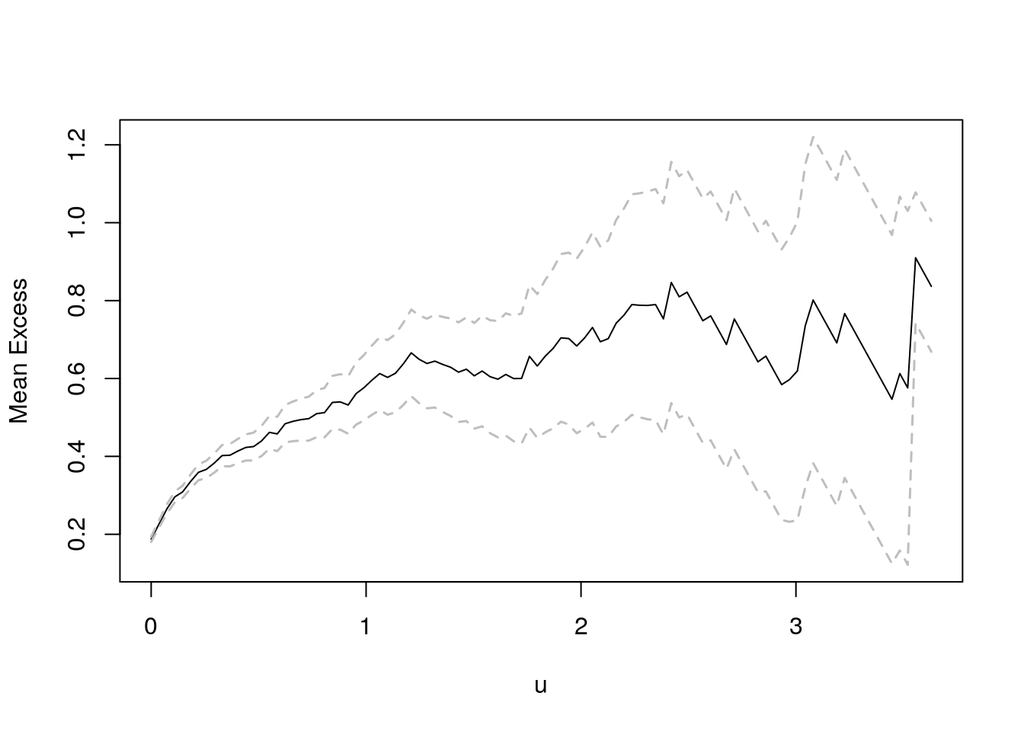

```r
mrlplot(Fort$Prec, xlab = 'u')
```

We should determine the threshold as the value above which the “plot should be approximately linear in ‘u’”, according to Coles.

What do folks think?

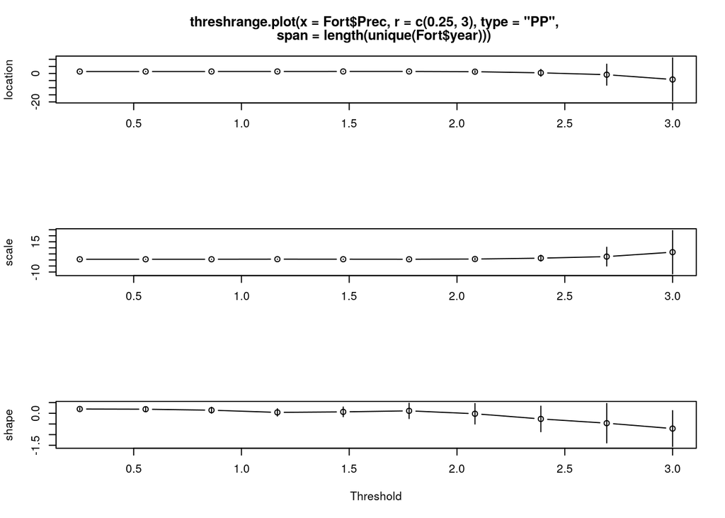

```r
## Use range of threshold from ~95%ile to ~99.9%ile
threshrange.plot(Fort$Prec, r = c(.25, 3), type = 'PP', span = length(unique(Fort$year)))
```

What do folks think?

# Some basic fitting with climextRemes

```r
## GEV
library(climextRemes)
gev_model <- fit_gev(FortMax$Prec, returnPeriod = 20, returnValue = 3.5,
             getParams = TRUE)
gev_model
```

```
## $mle
##  location     scale     shape
## 1.3467234 0.5328195 0.1736623
##
## $se_mle
##   location      scale      shape
## 0.06169221 0.04878825 0.09195978
##
## $nllh
## [1] 104.9645
##
## $returnValue
## [1] 3.417704
##
## $se_returnValue
## [1] 0.3329517
##
## $logReturnProb
## [1] -3.08499
##
## $se_logReturnProb
## [1] 0.3811034
##
## $logReturnPeriod
## [1] 3.08499
##
## $se_logReturnPeriod
## [1] 0.3811034
##
## $info
## $info$convergence
## [1] 0
##
## $info$counts
## function gradient
##       80       NA
##
## $info$message
## NULL
##
## $info$failure
## [1] FALSE
```

```r
## return value
gev_model$returnValue + c(-2,2)*gev_model$se_returnValue
```

```
## [1] 2.751800 4.083607
```

```r
## return probability
exp(gev_model$logReturnProb + c(-2,2)*gev_model$se_logReturnProb)
```

```
## [1] 0.02133948 0.09800048
```

```r
## return time
exp(gev_model$logReturnPeriod + c(-2,2)*gev_model$se_logReturnPeriod)
```

```
## [1] 10.20403 46.86149
```

```r
## POT
pot_model <- fit_pot(FortExc$Prec, threshold = threshold, nBlocks = nYears,
        returnPeriod = 20, returnValue = 3.5,
        firstBlock = min(FortExc$year), blockIndex = FortExc$year,
        getParams = TRUE, bootSE = TRUE)
## Note: 'blockIndex' allows block-bootstrapping by year
## unlike extRemes, climextRemes takes only the exceedances as input data
pot_model
```

```
## $mle
##  location     scale     shape
## 1.4566697 0.5369649 0.1025798
##
## $se_mle
##   location      scale      shape
## 0.06247136 0.10368571 0.13362426
##
## $nllh
## [1] 139.3451
##
## $returnValue
## [1] 3.321204
##
## $se_returnValue
## [1] 0.259506
##
## $logReturnProb
## [1] -3.232733
##
## $se_logReturnProb
## [1] 0.3966608
##
## $logReturnPeriod
## [1] 3.232733
##
## $se_logReturnPeriod
## [1] 0.3966608
##
## $info
## $info$convergence
## [1] 0
##
## $info$counts
## function gradient
##       68       NA
##
## $info$message
## NULL
##
## $info$failure
## [1] FALSE
##
##
## $se_mle_boot
##   location      scale      shape
## 0.08370725 0.10561896 0.09878108
##
## $se_returnValue_boot
##        20
## 0.2177946
##
## $se_logReturnProb_boot
##       3.5
## 0.3587704
##
## $se_logReturnPeriod_boot
##       3.5
## 0.3587704
##
## $numBootFailures
## [1] 0
```

```r
pot_model$returnValue + c(-2,2)*pot_model$se_returnValue_boot
```

```
## [1] 2.885615 3.756793
```

# Fitting with covariates (trends in this case)

```r
pot_model <- fit_pot(FortExc$Prec, x = data.frame(years = years), locationFun = ~years,
               threshold = threshold,
               nBlocks = nYears, blockIndex = FortExc$year, firstBlock = min(Fort$year),
               returnPeriod = 20, returnValue = 3.5,
               getParams = TRUE, xNew = data.frame(years = range(Fort$year)))
## Note: 'blockIndex' allows matching of observations to covariate ('x') values

pot_model$returnValue
```

```
## [1] 3.218000 3.409746
```

```r
exp(pot_model$logReturnPeriod)
```

```
## [1] 29.13729 22.58607
```

```r
# Trend assessment
```

```r
pot_model <- fit_pot(FortExc$Prec, x = data.frame(years = years), locationFun = ~years,
               threshold = threshold,
               nBlocks = nYears, blockIndex = FortExc$year, firstBlock = min(Fort$year),
               returnPeriod = 20, returnValue = 3.5,
               getParams = TRUE, xNew = data.frame(years = max(Fort$year)),
               xContrast = data.frame(years = min(Fort$year)))

pot_model$returnValueDiff
```

```
## [1] 0.191746
```

```r
pot_model$returnValueDiff + c(-2, 2)*pot_model$se_returnValueDiff
```

```
## [1] -0.2380645  0.6215564
```

```r
## Probability ratio (aka risk ratio) with uncertainty
exp(pot_model$logReturnProbDiff)
```

```
## [1] 1.290056
```

```r
exp(pot_model$logReturnProbDiff + c(-2, 2)*pot_model$se_logReturnProbDiff)
```

```
## [1] 0.7055648 2.3587400
```

extRemes also allows one to fit with covariates, specified in a similar way, though it has somewhat less richness in what it will directly estimate for you in terms of contrasts at different covariate values.

# Declustering to minimize temporal autocorrelation

```r
pot_model <- fit_pot(FortExc$Prec, x = data.frame(years = years), locationFun = ~years,
               threshold = threshold,
               nBlocks = nYears, blockIndex = FortExc$year, firstBlock = min(Fort$year),
               index = FortExc$obs,
               returnPeriod = 20, returnValue = 3.5,
               getParams = TRUE, xNew = data.frame(years = max(Fort$year)),
               xContrast = data.frame(years = min(Fort$year)),
               declustering = 'noruns')

pot_model$returnValueDiff
```

```
## [1] 0.1920966
```

```r
pot_model$returnValueDiff + c(-2, 2)*pot_model$se_returnValueDiff
```

```
## [1] -0.2421641  0.6263573
```

```r
## Probability ratio (aka risk ratio) with uncertainty
exp(pot_model$logReturnProbDiff)
```

```
## [1] 1.287798
```

```r
exp(pot_model$logReturnProbDiff + c(-2, 2)*pot_model$se_logReturnProbDiff)
```

```
## [1] 0.7025791 2.3604785
```

# Seasonal analysis (of summer precipitation)

Might be more interesting to analyze drought but for Fort Collins, the lower quantiles of summer precipitation are quite close to zero so not clear that EVA is appropriate.

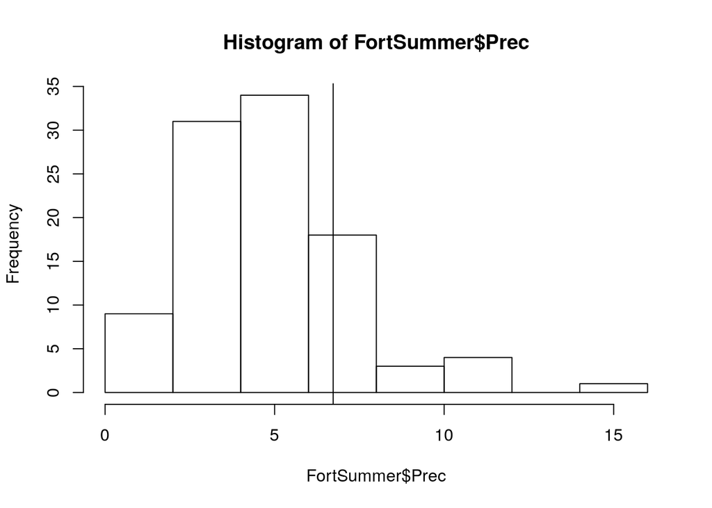

```r
summerData <- Fort[Fort$month %in% 6:8, ]  # June, July, August precipitation
FortSummer <- aggregate(Prec ~ year, data = summerData, sum)
## not-so-extreme threshold given limited obs when aggregated:
summerThreshold <- quantile(FortSummer$Prec, 0.8)
hist(FortSummer$Prec)
abline(v = summerThreshold)
```

```r
FortSummerExc <- FortSummer[FortSummer$Prec > summerThreshold, ]
FortSummerExc
```

```
##    year  Prec
## 9  1908  6.94
## 19 1918  7.92
## 22 1921  7.61
## 24 1923 11.35
## 31 1930  7.95
## 33 1932  6.94
## 42 1941  6.96
## 46 1945  6.82
## 50 1949 10.18
## 52 1951 11.47
## 62 1961  9.91
## 66 1965  8.00
## 68 1967  8.18
## 71 1970  6.75
## 78 1977  7.38
## 80 1979  7.21
## 83 1982  9.65
## 92 1991  7.14
## 93 1992 10.38
## 98 1997 14.79
```

```r
## Stationary model
pot_model <- fit_pot(FortSummerExc$Prec, threshold = summerThreshold,
               nBlocks = nYears, blockIndex = FortSummerExc$year, firstBlock = min(Fort$year),
               returnPeriod = 20, returnValue = 10, bootSE = TRUE)
```

[output not shown]

[output cut: 120 more lines]

[output not shown]

```r
## Note: each year (single observation) treated as a block, so return probability
## can be interpreted as probability of exceeding a value in a single year.

exp(pot_model$logReturnProb)  ## return probability for 10 inch summer precipitation for 1999
```

```
## [1] 0.03546843
```

```r
exp(pot_model$logReturnProb + c(-2, 2) * pot_model$se_logReturnProb)
```

```
## [1] 0.01472325 0.08544372
```

```r
exp(pot_model$logReturnProb + c(-2, 2) * pot_model$se_logReturnProb_boot)
```

```
## [1] 0.01268962 0.09913687
```

```r
pot_model$numBootFailures  # perhaps a sign for concern
```

```
## [1] 34
```

# Fitting with replicates

climextRemes is designed to handle model ensembles in a statistically sound way by treating each ensemble member as a replicate, and thereby as a contribution to the overall likelihood.

We’ll demonstrate with a 50-member CAM5 all-forcings ensemble for 1960-2013. The variable of interest is March-August precipitation over the US states of Texas and Oklahoma.

```r
library(ncdf4)
nc_all <- nc_open('pr_MarAug_LBNL_CAM5-1-1degree_All-Hist_est1_v2-0_196001-201312.nc')
all <- ncvar_get(nc_all, 'pr', start=c(1,1), count = c(-1,-1))

## Preprocessing to extract 50 ensemble members available for full 1960-2013 period
avail <- c(1:10, 36:50, 61:70, 86:100)
startYear <- 1960
endYear <- 2013
fullYears <- startYear:endYear
nYears <- length(fullYears)
baseline <- 1961:2010
baseIndices <- baseline - startYear + 1

## 54 years (rows) with 50 ensemble members (columns)
all <- all[ , avail]

## Calculate (relative) precipitation anomalies
mn <- mean(all[baseIndices, ])
allAnom <- all / mn

## Set up replicated data in format required
nReplicates <- ncol(allAnom)         # 50 replicates (ensemble members)
threshold <- quantile(allAnom, .02)   # 2th percentile of distribution
allAnomVec <- c(allAnom)  ## string out data in a column-wise vector
blockIndex <- rep(fullYears, nReplicates)
replicateIndex <- rep(1:nReplicates, each = nYears)
sub <- which(allAnomVec < threshold)

allAnomVec[1:20]
```

```
##  [1] 0.8262629 0.8777795 0.8298955 1.1947543 1.0064854 1.0855576 0.8348449
##  [8] 0.7565521 0.8287725 0.8646086 1.0036329 0.9268273 1.1244315 0.9843667
## [15] 0.6593363 0.9692242 0.7669965 0.9825030 0.8532302 1.1479947
```

```r
blockIndex[1:20]
```

```
##  [1] 1960 1961 1962 1963 1964 1965 1966 1967 1968 1969 1970 1971 1972 1973
## [15] 1974 1975 1976 1977 1978 1979
```

```r
replicateIndex[1:20]
```

```
##  [1] 1 1 1 1 1 1 1 1 1 1 1 1 1 1 1 1 1 1 1 1
```

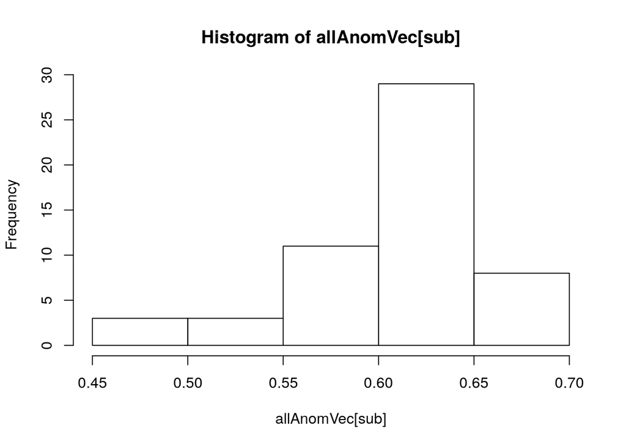

```r
hist(allAnomVec[sub])
```

```r
blockIndex[sub]
```

```
##  [1] 1983 1988 2007 2008 1964 1973 1961 1983 1978 1989 2004 1998 1964 2013
## [15] 1987 1972 1975 1998 1999 2005 2008 2011 2011 2010 1963 1983 2011 1969
## [29] 2003 1985 2011 1998 2011 2013 1971 1963 1964 1997 1999 1977 2009 1995
## [43] 1963 2013 1983 1986 1988 2012 1969 1986 1998 1964 2011 2013
```

```r
replicateIndex[sub]
```

```
##  [1]  1  3  4  4  5  5  7  9 11 11 12 13 18 18 20 21 21 21 21 21 21 21 22
## [24] 23 25 25 27 28 28 29 29 30 30 30 33 36 37 37 37 41 43 44 47 47 48 48
## [47] 48 48 49 49 49 50 50 50
```

```r
out <- fit_pot(allAnomVec[sub], threshold = threshold,
               x = data.frame(years = fullYears), locationFun = ~years,
               nBlocks = nYears, blockIndex = blockIndex[sub], firstBlock = startYear,
               replicateIndex = replicateIndex[sub], nReplicates = nReplicates,
               returnPeriod = 20, returnValue = 0.6,
               xNew = data.frame(years = endYear),
               xContrast = data.frame(years = startYear),
               upperTail = FALSE)
## Note: linear model for location parameter
## Note: 'replicateIndex' and 'nReplicates' allow for correct handling of model ensembles
## Note: 'upperTail = FALSE' for analysis of lower tail extremes

out$returnValue           ## 20-year return value for 2013
```

```
##  Estimate
## 0.6869676
```

```r
exp(out$logReturnPeriod)   ## Return period for 2013 for anomaly of 60% average precipitation
```

```
## [1] 101.0662
```

```r
exp(out$logReturnPeriod + c(-2, 2) * out$se_logReturnPeriod)
```

```
## [1]  55.76736 183.16038
```

```r
exp(out$logReturnProbDiff)  ## Ratio of return probabilities for end year compared to begin year
```

```
## [1] 2.592589
```

```r
exp(out$logReturnProbDiff + c(-2, 2) * out$se_logReturnProbDiff)  ## confidence interval
```

```
## [1] 0.9587602 7.0106368
```

Note that with an ensemble we have the statistical power to estimate probabilities of fairly extreme events at the seasonal/annual time scale.

# Event attribution: 2011 Texas heatwave/drought using binomial counting

Now consider an event attribution study, using an ensemble of model simulations only for 2011, to try to understand the 2011 Texas heatwave/drought.

Instead of doing EVA (which requires the event be extreme in both factual and counterfactual), simply count the number of exceedances and use epidemiological/biostatistical methods for estating risk ratios (borrowed from analysis of biomedical experiments).

```r
nc_all <- nc_open('pr_MarAug_LBNL_CAM5-1-1degree_All-Hist_est1_v2-0_196001-201312.nc')
nc_nat <- nc_open('pr_MarAug_LBNL_CAM5-1-1degree_Nat-Hist_CMIP5-est1_v2-0_196001-201312.nc')

all <- ncvar_get(nc_all, 'pr', start=c(1,1), count = c(-1,-1))
nat <- ncvar_get(nc_nat, 'pr', start=c(1,1), count = c(-1,-1))

avail <- c(1:10, 36:50, 61:70, 86:100)

startYr = 1960
endYr = 2013
fullYrs = startYr:endYr
baseline = 1961:2010
baseIndices <- baseline - startYr + 1

## Calculate anomalies based on baseline period, 50 member full ensemble
mnModel = mean(all[baseIndices, avail])

allAnom = all / mnModel
natAnom = nat / mnModel  # relative to all forcings baseline

eventYear <-  52 # 2011
level <- 0.9  # 90% confidence intervals

## Restrict to 2011
allAnom <- allAnom[eventYear, ]
natAnom <- natAnom[eventYear, ]

## Actual event of 0.4 (40% normal precipitation) has no exceedances
## in either scenario, so use slightly less extreme definition
event <- 0.5

yA <- sum(allAnom < event)
yN <- sum(natAnom < event)
n <- length(allAnom)

print(yA)  # factual events
```

```
## [1] 2
```

```r
print(yN)  # counterfactual events
```

```
## [1] 1
```

```r
print(n)   # sample size (# ensemble members)
```

```
## [1] 400
```

```r
result <- calc_riskRatio_binom(y = c(yA, yN), n = rep(n, 2),
                                    ciType = c('koopman', 'lrt'),
                                    ciLevel = level, lrtControl = list(bounds = c(0.01, 500)))
result$riskRatio
```

```
## [1] 2
```

```r
result$ci_riskRatio_lrt  ## likelihood-ratio based interval
```

```
## [1]  0.2860612 22.9271241
```

```r
result$ci_riskRatio_koopman  ## Koopman-based interval
```

```
## [1]  0.3406993 11.7544875
```

```r
## Consider even less extreme event of 0.6

event <- 0.6

yA <- sum(allAnom < event)
yN <- sum(natAnom < event)
n <- length(allAnom)

print(yA)  # factual events
```

```
## [1] 15
```

```r
print(yN)  # counterfactual events
```

```
## [1] 8
```

```r
print(n)   # sample size (# ensemble members)
```

```
## [1] 400
```

```r
result <- calc_riskRatio_binom(y = c(yA, yN), n = rep(n, 2),
                                    ciType = c('koopman', 'lrt'),
                                    ciLevel = level, lrtControl = list(bounds = c(0.01, 500)))
result$riskRatio
```

```
## [1] 1.875
```

```r
result$ci_riskRatio_lrt  ## likelihood-ratio based interval
```

```
## [1] 0.9389007 3.9546378
```

```r
result$ci_riskRatio_koopman  ## Koopman-based interval
```

```
## [1] 0.9353148 3.7658389
```

# Event attribution: 2011 Texas heatwave/drought using EVA

We can also use extreme value analysis to calculate the risk ratio, if the event is extreme in both scenarios.

I just found a bug (to be fixed in the next version of climextRemes) when using the likelihood-ratio-based interval with the lower-tail extreme, so we need to pull in the fixed version of the function.

```r
source('calc_riskRatio_pot_fixed.R')
```

Now let’s proceed

```r
thrAll <- quantile(allAnom, 0.1)
thrNat <- quantile(natAnom, 0.1)

y1 <- allAnom[allAnom < thrAll]
y2 <- natAnom[natAnom < thrNat]

result <- calc_riskRatio_pot(0.4, y1 = allAnom[allAnom < thrAll], y2 = natAnom[natAnom < thrNat],
                                  threshold1 = thrAll, threshold2 = thrNat,
                                  nBlocks1 = 1, nBlocks2 = 1,
                                  upperTail = FALSE,
                                  ciType = c('delta'))
result$ci_riskRatio_delta
```

```
##         0.05         0.95
## 1.375555e-05 4.444170e+07
```

That’s not at all informative. (And if we tried to use the LR-based confidence interval, the optimization involved in the calculation would fail.)

Let’s try a less extreme event definition.

```r
result <- calc_riskRatio_pot(0.5, y1 = allAnom[allAnom < thrAll],
                                  y2 = natAnom[natAnom < thrNat],
                                  threshold1 = thrAll, threshold2 = thrNat,
                                  nBlocks1 = 1, nBlocks2 = 1,
                                  upperTail = FALSE,
                                  ciType = c('delta','lrt'))
result$ci_riskRatio_delta
```

```
##       0.05       0.95
##  0.3714756 11.7324030
```

```r
result$ci_riskRatio_lrt
```

```
##       0.05       0.95
##  0.8231109 53.6604719
```

Unfortunately, there’s still a fair amount of uncertainty.

# Breakout

Work more with the examples provided above or apply the software tools to your own data or to the California winter (DJF) precipitation data for 1949-2017 [here](https://www.stat.berkeley.edu/transfer/CA_precip.Rda'). The code in `prep_data.R` will help with cleaning/rearranging.

One thing worth doing would be assessing the peaks-over-threshold diagnostics for the summer total precipitation data given the small sample sizes and not-so-extreme threshold.

Let me know as you have questions.